# Data Science Report

- Show All Code
- Hide All Code
- View Source

Author

Zheng Ren

Published

August 7, 2024

# 1 Aim

In this report, I aim to explore two data science-related questions: 1) How has the **death toll** caused by natural disasters in the **20th and 21st centuries** changed over the years? 2) How does the performance of the **gradient descent algorithm** in searching for the minimum of a loss function depend on the **learning rate**?

# 2 Question 1

## 2.1 Step 1: Web Scripting and Data Cleaning

In this step, I used a web scripting method in R to get the death toll data for the 20th and 21st centuries from the [Wikipedia](https://en.wikipedia.org/wiki/List_of_natural_disasters_by_death_toll) page on natural disasters. After some data cleaning, below is a snapshot of the clean data.

```r
url = "https://en.wikipedia.org/wiki/List_of_natural_disasters_by_death_toll"
page = read_html(url)
tables = page %>% html_nodes("table")
twenty_centry = tables[[3]] %>% html_table(fill = TRUE)
twenty_first_centry = tables[[4]] %>% html_table(fill = TRUE)
## Data cleaning
twenty_centry$`Death toll` = sapply(twenty_centry$`Death toll`, function(x){
  x = gsub(",", "", x)
  x = gsub("\\+", "", x)
  if(grepl("–", x)){
    a = as.numeric(str_split(x, "–")[[1]][1])
    b = as.numeric(str_split(x, "–")[[1]][2])
    x = (a+b)/2
  }else if(grepl("-", x)){
    a = as.numeric(str_split(x, "-")[[1]][1])
    b = as.numeric(str_split(x, "-")[[1]][2])
    x = (a+b)/2
  }else if(grepl("\\[", x)){
    x = gsub("\\[.*\\]", "", x)
  }
  return(as.numeric(x))
}, USE.NAMES = FALSE)

twenty_first_centry$`Death toll` = sapply(twenty_first_centry$`Death toll`, function(x){
  x = gsub(",", "", x)
  x = gsub("\\+", "", x)
  x = gsub("\\(.*\\)", "", x)
  if(grepl("–", x)){
    a = as.numeric(str_split(x, "–")[[1]][1])
    b = as.numeric(str_split(x, "–")[[1]][2])
    x = (a+b)/2
  }else if(grepl("-", x)){
    a = as.numeric(str_split(x, "-")[[1]][1])
    b = as.numeric(str_split(x, "-")[[1]][2])
    x = (a+b)/2
  }else if(grepl("\\[", x)){
    x = gsub("\\[.*\\]", "", x)
  }
  return(as.numeric(x))
}, USE.NAMES = FALSE)

combined_df = rbind(twenty_centry, twenty_first_centry)
combined_df$Type = sapply(combined_df$Type, function(x){
  if(x == "Heat Wave"){return("Heat wave")}else if(x == "Earthquake, Tsunami"){
    return("Earthquake")}else if(x == "Tropical cyclone, Flood"){return("Tropical cyclone")}else{return(x)}
}, USE.NAMES = FALSE)
kable(combined_df %>% head(10), align = "c") %>% kable_styling(bootstrap_options = "striped")
```

| Year | Death toll | Event | Countries affected | Type | Date |
| --- | --- | --- | --- | --- | --- |
| 1900 | 9000 | 1900 Galveston hurricane | United States | Tropical cyclone | September 9 |
| 1901 | 9500 | 1901 eastern United States heat wave | United States | Heat wave | June–July |
| 1902 | 29000 | 1902 eruption of Mount Pelée | Martinique | Volcanic eruption | April–August |
| 1903 | 3500 | 1903 Manzikert earthquake | Turkey | Earthquake | April 28 |
| 1904 | 400 | 1904 Sichuan earthquake | China | Earthquake | August 30 |
| 1905 | 20000 | 1905 Kangra earthquake | India | Earthquake | April 4 |
| 1906 | 15000 | 1906 Hong Kong typhoon | Hong Kong,China | Tropical cyclone | September 18 |
| 1907 | 13500 | 1907 Qaratog earthquake | Uzbekistan | Earthquake | October 21 |
| 1908 | 78500 | 1908 Messina earthquake | Italy | Earthquake | December 28 |
| 1909 | 7000 | 1909 Borujerd earthquake | Iran | Earthquake | January 23 |

## 2.2 Step 2: Visualization

In this step, we aim to further investigate how the death toll numbers have changed over the years for different types of disasters in the 20th and 21st centuries. A bar plot can be found below.

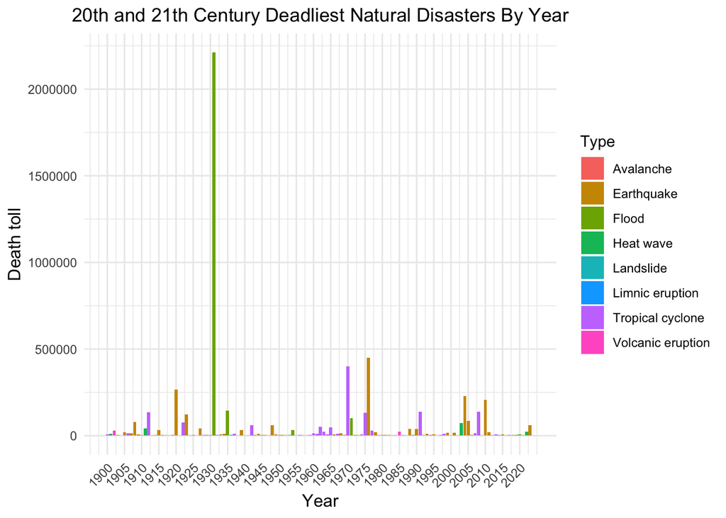

Figure 1: Death Toll Distribution

```r
ggplot(combined_df, aes(x = Year, y = `Death toll`, fill = Type)) +
  geom_bar(stat = "identity", position = "stack") +
  labs(title = "20th and 21th Century Deadliest Natural Disasters By Year") +
  scale_x_continuous(breaks = seq(min(combined_df$Year), max(combined_df$Year), by = 5)) +
  theme_minimal() +
  theme(
    plot.title = element_text(hjust = 0.5),
    axis.text.x = element_text(angle = 45, hjust = 1),
    axis.title.x = element_text(size = 12),
    axis.title.y = element_text(size = 12)
  )
```

**Key Findings**

Some key findings can be found below:

- In **1931**, the **flood** caused a significant number of deaths, far more than in any other year in the two centuries.
- **Earthquakes**, **floods**, and **tropical cyclones** are three types of disasters that have been seen more often in the past two centuries compared to other types. Among these three, **earthquakes** are the most common.
- **Tropical cyclones** were seen more often from the **1950s to the 1980s**.

# 3 Question 2

## 3.1 One Example Test

Below is an example test to show the overall performance of the gradient descent algorithm in searching for the minimum of the loss function: $L(b) = \|y - b x\|^2$. In this example, x and y both have a length of 100, and I choose a learning rate of 0.01 with the maximum number of iterations set to 1000 and the tolerance set to $1*10^{-6}$.

```r
## Create the gradient descent function
gradient_descent = function(x, y, e = 0.01, iter = 1000, tol = 1e-6) {
  b = 0
  for (i in 1:iter) {
    gradient = -2 * sum(x * (y - b * x))
    b_new = b - e * gradient
    if (abs(b_new - b) < tol) {
      break
    }
    b = b_new
  }
  return(b)
}

## Test the function
test_run = function(n, e, s = 123){
  set.seed(s)
  x = rnorm(n)
  y = rnorm(n)
  true_b = sum(x*y)/sum(x^2)
  estimated_b = gradient_descent(x, y, e)
  return(list("true" = true_b, "estimated" = estimated_b))
}

### One test example
test_illustration = test_run(n = 100, e = 0.01)
true_b = test_illustration$true
estimated_b = test_illustration$estimated
cat("True b:", true_b, "\nEstimated b:", estimated_b, "\n")
```

```
True b: -0.06362789
Estimated b: -0.06362838
```

As we can see in this example, the overall accuracy of the estimated b is excellent.

## 3.2 Learning Rate Investigation

I then want to further examine how the performance of the algorithm depends on the learning rate e. Below are scatter plots depicting how the estimated b values change with different learning rates as well as different vector lengths. For the purpose of illustration, I chose n to be 10, 100, and 1000.

**n = 10**

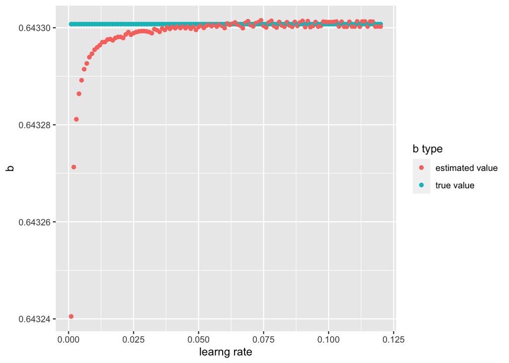

Figure 2: Estimated b Distribution: n = 10

```r
es = seq(0.001, 0.12, by = 0.001)
test_list = lapply(1:length(es), function(i) test_run(n = 10, e = es[i], s = 123))
true_bs = lapply(1:length(test_list), function(i) test_list[[i]]$true) %>% unlist()
estimated_bs = lapply(1:length(test_list), function(i) test_list[[i]]$estimated) %>% unlist()
test_df = data.frame(cbind(es, true_bs, estimated_bs))
test_df = test_df %>% pivot_longer(cols = c(2:3), names_to = "type", values_to = "b") %>% mutate(type = case_when(type == "estimated_bs" ~ "estimated value",
                                                                                                                  type == "true_bs" ~ "true value"))
ggplot(test_df, aes(x = es, y = b, color = type)) +
  geom_point() +
  labs(x = "learng rate", y = "b", color = "b type")
```

**n = 100**

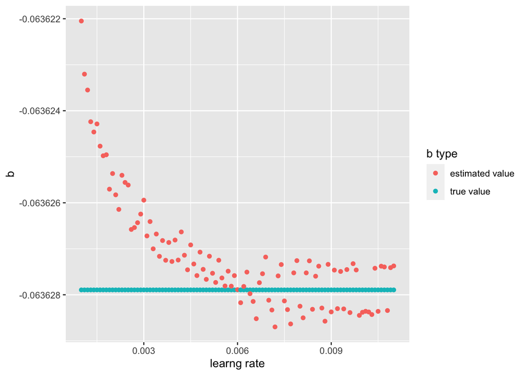

Figure 3: Estimated b Distribution: n = 100

```r
es = seq(0.001, 0.011, by = 0.0001)
test_list = lapply(1:length(es), function(i) test_run(n = 100, e = es[i], s = 123))
true_bs = lapply(1:length(test_list), function(i) test_list[[i]]$true) %>% unlist()
estimated_bs = lapply(1:length(test_list), function(i) test_list[[i]]$estimated) %>% unlist()
test_df = data.frame(cbind(es, true_bs, estimated_bs))
test_df = test_df %>% pivot_longer(cols = c(2:3), names_to = "type", values_to = "b") %>% mutate(type = case_when(type == "estimated_bs" ~ "estimated value",
                                                                                                                  type == "true_bs" ~ "true value"))
ggplot(test_df, aes(x = es, y = b, color = type)) +
  geom_point() +
  labs(x = "learng rate", y = "b", color = "b type")
```

**n = 1000**

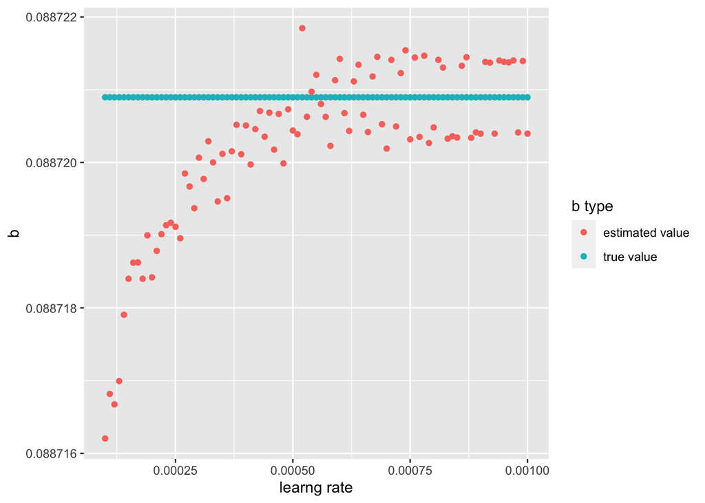

Figure 4: Estimated b Distribution: n = 1000

```r
es = seq(0.0001, 0.001, by = 0.00001)
test_list = lapply(1:length(es), function(i) test_run(n = 1000, e = es[i], s = 123))
true_bs = lapply(1:length(test_list), function(i) test_list[[i]]$true) %>% unlist()
estimated_bs = lapply(1:length(test_list), function(i) test_list[[i]]$estimated) %>% unlist()
test_df = data.frame(cbind(es, true_bs, estimated_bs))
test_df = test_df %>% pivot_longer(cols = c(2:3), names_to = "type", values_to = "b") %>% mutate(type = case_when(type == "estimated_bs" ~ "estimated value",
                                                                                                                  type == "true_bs" ~ "true value"))
ggplot(test_df, aes(x = es, y = b, color = type)) +
  geom_point() +
  labs(x = "learng rate", y = "b", color = "b type")
```

**Key Findings**

Some key findings can be found below:

- If the **learning rate is too large**, each update step can move far from its current position, pushing b further away and causing it to **diverge** to very large values. This can make the loss function increase rather than decrease or cause b to **oscillate around the minimum**.
- Different values of n are sensitive to different learning rates: as **n becomes larger**, the **learning rate needs to be smaller**, or the algorithm will diverge and fail.